# New Residential Sales Press Release

**Sponsored By:**

[figure not shown]

#### FOR IMMEDIATE RELEASE: Tuesday, August 25, 2026

## MONTHLY NEW RESIDENTIAL SALES, JULY 2026

August 25, 2026

CB26-128

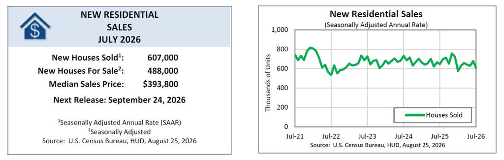

**New Home Sales**  
Sales of new single-family houses in July 2026 were at a seasonally-adjusted annual rate of 607,000, according to estimates released jointly today by the U.S. Census Bureau and the Department of Housing and Urban Development. This is 10.5 percent (±14.0 percent)* below the June 2026 rate of 678,000, and is 6.3 percent (±19.6 percent)* below the July 2025 rate of 648,000.  
**For Sale Inventory and Months’ Supply**  
The seasonally-adjusted estimate of new houses for sale at the end of July 2026 was 488,000. This is 1.9 percent (±1.2 percent) above the June 2026 estimate of 479,000, and is 1.6 percent (±4.0 percent)* below the July 2025 estimate of 496,000.  
This represents a supply of 9.6 months at the current sales rate. The months' supply is 12.9 percent (±21.3 percent)* above the June 2026 estimate of 8.5 months, and is 4.3 percent (±25.2 percent)* above the July 2025 estimate of 9.2 months.  
**Sales Price**  
The median sales price of new houses sold in July 2026 was $393,800. This is 2.3 percent (±7.4 percent)* below the June 2026 price of $403,100, and is 0.9 percent (±6.9 percent)* below the July 2025 price of $397,300. The average sales price of new houses sold in July 2026 was $508,800. This is 4.1 percent (±11.8 percent)* above the June 2026 price of $488,900, and is 5.4 percent (±13.1 percent)* above the July 2025 price of $482,800.

### Additional Release Materials

Current Survey Chart

Current Press Release (text and tables)

Current Press Release (tables)

Historical Time Series

Contact

**Data Inquiries**  
Economic Indicators Division  
Residential Construction Branch  
301-763-5160  
[email protected]  
**Media Inquiries**  
Public Information Office  
301-763-3030  
[email protected]

Related Information

[figure not shown]

[Economic Indicators](https://www.census.gov/economic-indicators/index.html)

[figure not shown]

Building Permits Survey

[figure not shown]

Survey of Construction

[figure not shown]

New Residential Construction

[figure not shown]

[Construction Spending](https://www.census.gov/construction/c30/c30index.html)

[figure not shown]

[figure not shown]